# Mobile App Mentions & Classification - Team 3

**Description**

For this analysis we leverage supervised learning techniques in order to create a model that will accurately classify future documents. We leverage NLP and tm packages in R, to create Text-Document Matrices. Then we combine our matrices with our existing data, in order to build out predictive models. Our model is applied to a training and test data set, as final test to verify performance.

**Corpus**

Our body of text/corpus are reviews and ratings for mobile apps in the Apple and Google Play stores. The code below ingests our text files, and then creates Document-term matrices, based on the open ended responses provided in our description field (MentionsTable$Description).

```r
#Corpus Import & Syntax
#fileencoding needs to be set to "latin1"
MentionsURL <-"https://raw.githubusercontent.com/Misterresearch/CUNY-Projects/master/App%20Mentions.csv"
MentionsTable <- read.csv(file = MentionsURL, header = TRUE, sep = ",", strip.white = TRUE, na.strings = "", fill = TRUE, fileEncoding = "latin1")
MentionsTable$description = as.character(MentionsTable$description)
#Create data frame
mentiondesc <- data.frame(MentionsTable$description)
#makes each row in data frame a document, required for subsequent statistical analysis.
mentiondesc <- Corpus(DataframeSource(mentiondesc))
#Corpus Loading, filtering and stemming code. See "Basic Text Mining" source in end notes.
mentiondesc <- tm_map(mentiondesc, removePunctuation)
#for(j in seq(mentiondesc))
#{
  #mentiondesc[[j]] <- gsub("/", " ", mentiondesc[[j]])
  #mentiondesc[[j]] <- gsub("@", " ", mentiondesc[[j]])
  #mentiondesc[[j]] <- gsub("\\|", " ", mentiondesc[[j]])
#}
mentiondesc <- tm_map(mentiondesc, removeNumbers)
mentiondesc <- tm_map(mentiondesc, tolower)
mentiondesc <- tm_map(mentiondesc, removeWords, stopwords("english"))
mentiondesc <- tm_map(mentiondesc, removeWords, c("none","the", "and", "or" , "http\\w*"))
mentiondesc <- tm_map(mentiondesc, stemDocument)
mentiondesc <- tm_map(mentiondesc, stripWhitespace)
mentiondesc <- tm_map(mentiondesc, PlainTextDocument)
#Single Term Matrices
mdtm <- DocumentTermMatrix(mentiondesc)
mtdm <- TermDocumentMatrix(mentiondesc)
mdtm
```

```
<<DocumentTermMatrix (documents: 4832, terms: 7152)>>
Non-/sparse entries: 41757/34516707
Sparsity           : 100%
Maximal term length: 218
Weighting          : term frequency (tf)
```

```r
mtdm
```

```
<<TermDocumentMatrix (terms: 7152, documents: 4832)>>
Non-/sparse entries: 41757/34516707
Sparsity           : 100%
Maximal term length: 218
Weighting          : term frequency (tf)
```

```r
#Sparcity settng adjustments
mentionstdm2 <- removeSparseTerms(mtdm, .97)
mentionsdtm2 <- removeSparseTerms(mdtm, .97)
mentionsfreq <- rowSums(as.matrix(mtdm))
#findFreqTerms(mentionstdm2, lowfreq = 1)
```

**Word Frequency & Visualization**

Below is a series of frequency charts on single words and bi grams to help us understand what words and terms are used most, and cluster together.

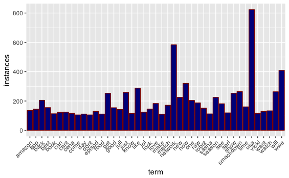

```r
#Single Term Frequency Charts
tf <- data.frame(term = names(mentionsfreq), instances=mentionsfreq)
subset(tf, mentionsfreq>100) %>%
  ggplot(aes(term,instances)) +
  geom_bar(stat="identity", fill="darkblue", colour="darkred") +
  theme(axis.text.x=element_text(angle = 45, hjust = 1))
```

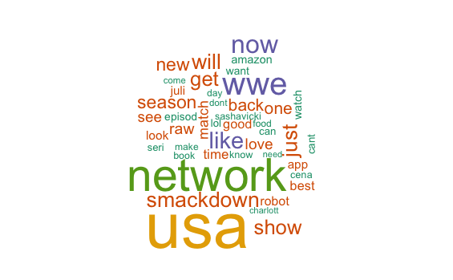

```r
#Single Term Word Clouds
wordcloud(names(mentionsfreq), mentionsfreq, min.freq = 100, scale=c(5, .1), colors=brewer.pal(6, "Dark2"))
```

```r
#Single Term Correlation Analysis
findAssocs(mtdm, c("Twitter", "Amazon", "chromecast"), corlimit = .2)
```

```
$Twitter
numeric(0)

$Amazon
numeric(0)

$chromecast
numeric(0)
```

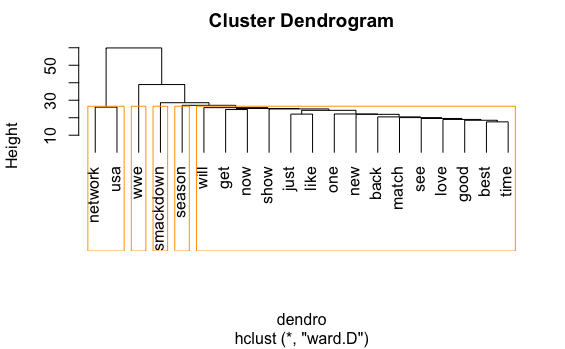

```r
#Single Term Cluster Analysis, requires Document-Text Matrix
dendro <- dist(t(mentionsdtm2), method="euclidean")
cluster <- hclust(d=dendro, method="ward.D")
plot(cluster, hang=-1)
rect.hclust(cluster, k=5, border="orange")
```

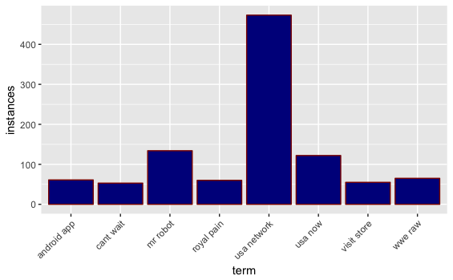

```r
#Bigram Corpus, see source for "Bigram Text-Document Matrices" in endnotes
BigramTokenizer <-
     function(x)
        unlist(lapply(ngrams(words(x), 2), paste, collapse = " "), use.names = FALSE)
mtdm2 <- TermDocumentMatrix(mentiondesc, control = list(tokenize = BigramTokenizer))
mdtm2 <- DocumentTermMatrix(mentiondesc, control = list(tokenize = BigramTokenizer))
mentionsfreq2 <- rowSums(as.matrix(mtdm2))
#Bigram Frequency Chart
tf <- data.frame(term = names(mentionsfreq2), instances=mentionsfreq2)
subset(tf, mentionsfreq2>50) %>%
  ggplot(aes(term,instances)) +
  geom_bar(stat="identity", fill="darkblue", colour="darkred") +
  theme(axis.text.x=element_text(angle = 45, hjust = 1))
```

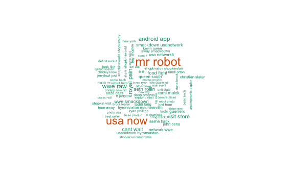

```r
#Bigram Word Cloud
wordcloud(names(mentionsfreq2), mentionsfreq2, min.freq = 25, scale=c(5, .1), colors=brewer.pal(6, "Dark2"))
```

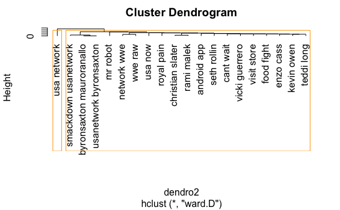

```r
#Bigram Dendrogram
mdtm2a <- removeSparseTerms(mdtm2, .993)
dendro2 <- dist(t(mdtm2a), method="euclidean")
cluster <- hclust(d=dendro2, method="ward.D")
plot(cluster, hang=-1)
rect.hclust(cluster, k=2, border="orange")
```

**Mentions Classification & Analysis**

Leveraging the sentiment corpus for negative and positive terms provided by Hu * Liu, and the tm_term_score function to allocate an integer value for each document. Once we’ve derived a score, then we create two variables “pos” and “neg”, that become added to our data frame and as an independent variable in predictive model. For this analysis, we’ve also derived a custom variable called “sentiment”, based on the ratio of “pos” to “neg” comments.

```r
#pos and neg sentiment sourced from Hu and Liu
#header notes removed from source file, adjust file path
pos_words = read.table("/Users/digitalmarketer1977/Desktop/positive-words.txt", header = F, stringsAsFactors = F)[, 1]
neg_words = read.table("/Users/digitalmarketer1977/Desktop/negative-words.txt", header = F, stringsAsFactors = F)[, 1]
```

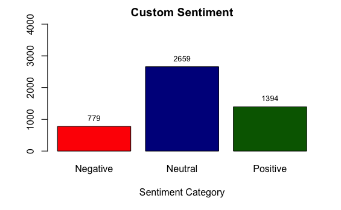

```r
MentionsTable$neg = sapply(mentiondesc, tm_term_score, neg_words)
MentionsTable$pos = sapply(mentiondesc, tm_term_score, pos_words)
#Raw Sum of Neg vs. Pos Comments
sumpos <- sum(MentionsTable$pos)
sumneg <- sum(MentionsTable$neg)
#sumcomments <- barplot(c(sumneg,sumpos),col = c("red","darkgreen"), ylim = c(0,3500))
#text(x = sumcomments, y = c(sumneg,sumpos),labels = c(sumneg,sumpos), pos = 3 , cex = .8, col = "black")
#Sentiment Classification & Analysis
MentionsTable$sentiment = MentionsTable$pos/MentionsTable$neg
MentionsTable$sentiment[MentionsTable$sentiment > 1.50] <- "Positive"
MentionsTable$sentiment[(MentionsTable$sentiment <= 1.50) & (MentionsTable$sentiment >= .50)] <- "Neutral"
MentionsTable$sentiment[MentionsTable$sentiment == "NaN"] <- "Neutral"
MentionsTable$sentiment[MentionsTable$sentiment < .50] <- "Negative"
sentiment <- table(MentionsTable$sentiment)
myValues <- barplot(sentiment, main="Custom Sentiment", xlab = "Sentiment Category", col=c("red","darkblue", "darkgreen"), border = "black", ylim = c(0,4000))
text(x = myValues, y = sentiment, labels = sentiment, pos = 3, cex = .8, col = "black")
```

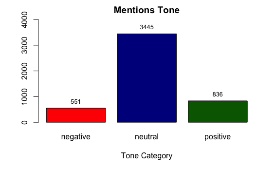

```r
tone <- table(MentionsTable$tone)
myValuesB <- barplot(tone, main="Mentions Tone", xlab = "Tone Category", col=c("red","darkblue","darkgreen"), border = "black", ylim = c(0,4000))
text(x = myValuesB, y = tone, labels = tone, pos = 3, cex = .8, col = "black")
```

**Predictive Model**

By appending Document Term Matrices to our existing data frame, essentially as dummy variables. We’re now able to combine the most of frequent terms that we’ve found in our corpus from app feedback, along with the “pos” & “neg” scores derived from the generic sentiment corpus from Hu & Liu, to build out a more robust model.

The model we used for our tree and our final predictive model was “sentiment ~ neg + pos + wwe + usa + smackdown”.

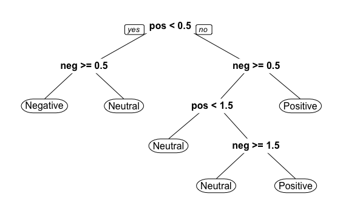

```r
#append to data frame
MentionsTable = cbind(MentionsTable, as.matrix(mentionsdtm2))
MentionsTable$tone = as.factor(MentionsTable$tone)
id_train <- sample(nrow(MentionsTable),nrow(MentionsTable)*0.80)
MentionsTable.train = MentionsTable[id_train,]
MentionsTable.test = MentionsTable[-id_train,]
MentionsTable.tree = rpart(sentiment ~ neg + pos + wwe + usa + smackdown,  method = "class", data = MentionsTable.train);
prp(MentionsTable.tree)
```

Conclusion & Insights

[output not shown]

Code Source: [Basic Text Mining in R](https://rstudio-pubs-static.s3.amazonaws.com/132792_864e3813b0ec47cb95c7e1e2e2ad83e7.html)

Code Source: [Bigram Text-Document Matrices](http://tm.r-forge.r-project.org/faq.html#Bigrams)

Reference: Automated Data Collection with R, Wiley (2015)

Code Source: [Predictive Modeling](https://rstudio-pubs-static.s3.amazonaws.com/132792_864e3813b0ec47cb95c7e1e2e2ad83e7.html)

Data Source: Minqing Hu and Bing Liu. “Mining and Summarizing Customer Reviews.”